## Описание данных

# Страны

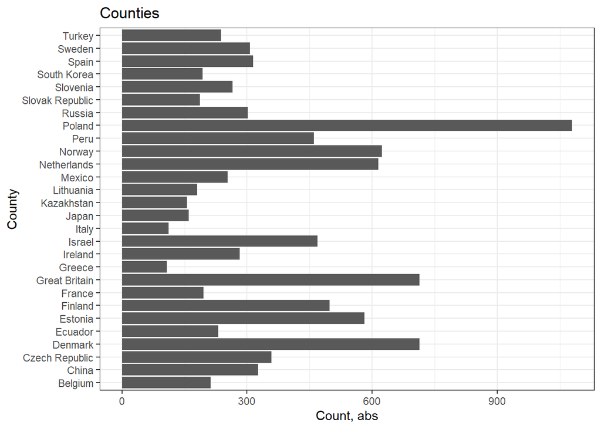

```r
data_w <- remove_all_labels(data_w)
ggplot(data = data_w) +
  geom_histogram(mapping = aes(CNTRYID), stat = 'count') +
  theme_bw() +
  coord_flip() +
  labs(title = 'Counties', y = 'Count, abs', x = 'County')
```

> В рамках исследования были отобраны 10135 наблюдений (нет пропущенных значений по признакам пола, возраста, образования, переменной LEARNATWORK).

# Пол

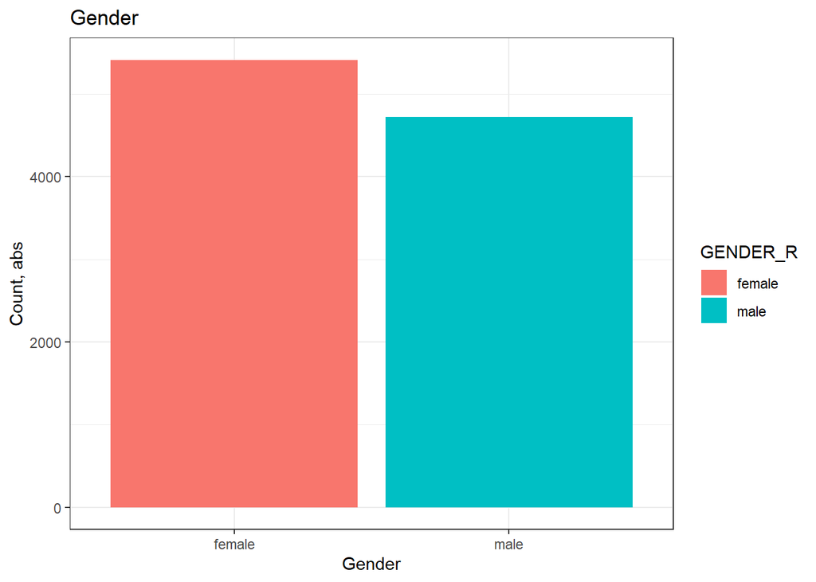

```r
ggplot(data = data_w) +
  geom_histogram(mapping = aes(GENDER_R, fill=GENDER_R), stat = 'count') +
  theme_bw() +
  labs(title = 'Gender', y = 'Count, abs', x = 'Gender')
```

# Возраст

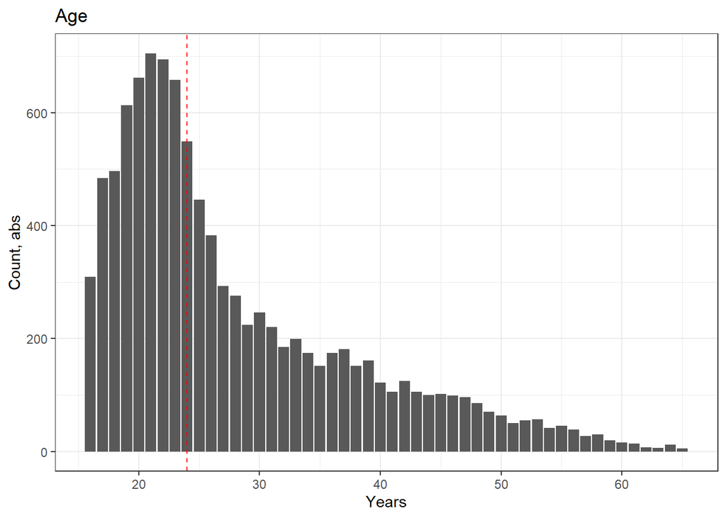

```r
ggplot(data = data_w) +
  geom_histogram(mapping = aes(AGE_R), stat = 'count') +
  theme_bw() +
  labs(title = 'Age', y = 'Count, abs', x = 'Years') +
  geom_vline(xintercept = median(data_w$AGE_R),
             color = "red",
             lty = 2)
```

> По возрасту наблюдения распределены логнормально. Выборка смещена в сторону молодых людей.

# Образование

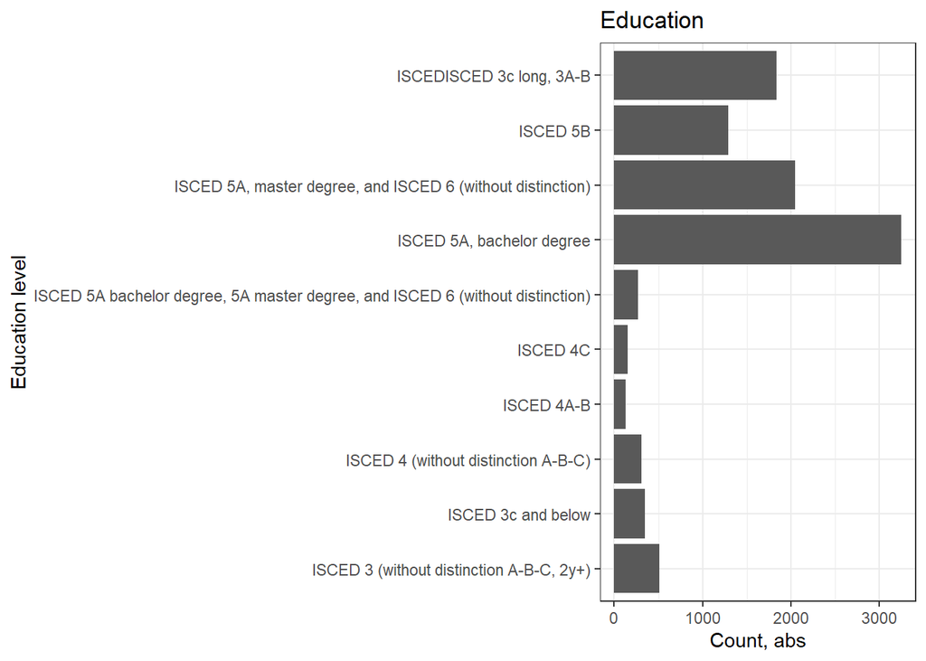

```r
ggplot(data = data_w) +
  geom_histogram(mapping = aes(B_Q02b_C), stat = 'count') +
  theme_bw() +
  coord_flip() +
  labs(title = 'Education', y = 'Count, abs', x = 'Education level')
```

# Описательные статистики

```r
summary(data_w)
```

```
##    CNTRYID              AGE_R         GENDER_R           B_Q02b_C
##  Length:10135       Min.   :16.00   Length:10135       Length:10135
##  Class :character   1st Qu.:20.00   Class :character   Class :character
##  Mode  :character   Median :24.00   Mode  :character   Mode  :character
##                     Mean   :27.91
##                     3rd Qu.:33.00
##                     Max.   :65.00
##   LEARNATWORK
##  Min.   :-0.6436
##  1st Qu.: 1.5289
##  Median : 2.0698
##  Mean   : 2.1551
##  3rd Qu.: 2.6251
##  Max.   : 4.1625
```

```r
table(data_w$CNTRYID)
```

```
##
##         Belgium           China  Czech Republic         Denmark         Ecuador
##             213             326             359             714             231
##         Estonia         Finland          France   Great Britain          Greece
##             582             498             195             714             107
##         Ireland          Israel           Italy           Japan      Kazakhstan
##             282             469             112             160             156
##       Lithuania          Mexico     Netherlands          Norway            Peru
##             180             253             615             624             460
##          Poland          Russia Slovak Republic        Slovenia     South Korea
##            1079             302             187             265             193
##           Spain          Sweden          Turkey
##             315             307             237
```

```r
table(data_w$GENDER_R)
```

```
##
## female   male
##   5414   4721
```

```r
table(data_w$B_Q02b_C)
```

```
##
##                                      ISCED 3 (without distinction A-B-C, 2y+)
##                                                                           508
##                                                            ISCED 3c and below
##                                                                           351
##                                           ISCED 4 (without distinction A-B-C)
##                                                                           310
##                                                                    ISCED 4A-B
##                                                                           131
##                                                                      ISCED 4C
##                                                                           150
## ISCED 5A bachelor degree, 5A master degree, and ISCED 6 (without distinction)
##                                                                           266
##                                                     ISCED 5A, bachelor degree
##                                                                          3248
##                    ISCED 5A, master degree, and ISCED 6 (without distinction)
##                                                                          2049
##                                                                      ISCED 5B
##                                                                          1289
##                                                      ISCEDISCED 3c long, 3A-B
##                                                                          1833
```

# Коррелеяции

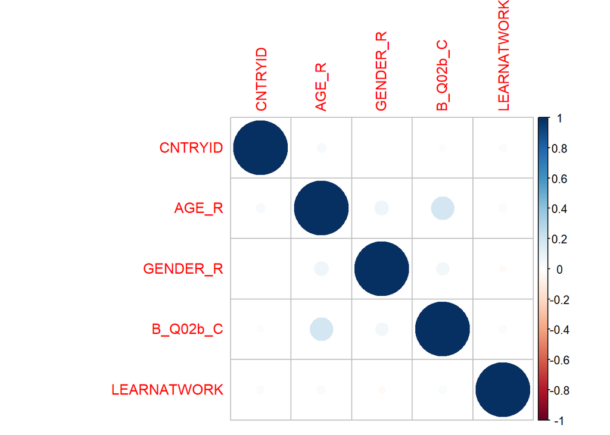

```r
data.cor <- cor(data)
corrplot(data.cor)
```

## > Корреляции между переменными малые по величине. Наибольшая корреляционная связь наблюдается между возрастом и уровнем образования.

## Проверка статистических гипотез

# Разница между мужчинами и женщинами по признаку LEARNATWORK

```r
male <- data$LEARNATWORK[which(data$GENDER_R == 1)]
female <- data$LEARNATWORK[which(data$GENDER_R == 2)]
data.t.test <- t.test(male, female)
data.t.test
```

```
##
##  Welch Two Sample t-test
##
## data:  male and female
## t = 2.0368, df = 9998.3, p-value = 0.04169
## alternative hypothesis: true difference in means is not equal to 0
## 95 percent confidence interval:
##  0.001537524 0.080207331
## sample estimates:
## mean of x mean of y
##  2.176971  2.136098
```

> Для начала проводим t-test для двух групп: мужчин и женщин. Данный тест покажет, верна ли гипотеза о том, что пол как признак будет связан с значением индекса LEARNATWORK. T-test показывает, что существует статистически значимое различие в среднем значении индекса LEARNATWORK между мужчинами и женщинами. Значение p-value менее 0.05. Индекс LEARNATWORK выше у мужчин на 0.04.

## Хи-квадрат

> Хи-квадрат как показатель может показать наличие статистически значимой связи между переменными, но не покажет направление связи.

# Возраст

```r
chisq.test(data$AGE_R, data$LEARNATWORK)
```

```
##
##  Pearson's Chi-squared test
##
## data:  data$AGE_R and data$LEARNATWORK
## X-squared = 8266.7, df = 7595, p-value = 5.716e-08
```

> Расчет показателя хи-квадрат для переменных возраста и LEARNATWORK показывает наличие статистически значимой связи между двумия номинальными переменными. p-value меньше 0.05. Однако итоговое значение может быть некорректным.

# Образование

```r
chisq.test(data$B_Q02b_C, data$LEARNATWORK)
```

```
##
##  Pearson's Chi-squared test
##
## data:  data$B_Q02b_C and data$LEARNATWORK
## X-squared = 1832.2, df = 1395, p-value = 2.09e-14
```

> Расчет показателя хи-квадрат для переменных уровень образования и LEARNATWORK показывает наличие статистически значимой связи между двумия номинальными переменными. p-value меньше 0.05. Однако итоговое значение может быть некорректным.

## Регрессия - показатели

```r
data_w$CNTRYID <- as.factor(data_w$CNTRYID)
data_w$GENDER_R <- as.factor(data_w$GENDER_R)
data_w$B_Q02b_C <- as.factor(data_w$B_Q02b_C)
lm.model <- lm(data = data_w, LEARNATWORK~CNTRYID+AGE_R+GENDER_R+B_Q02b_C)
summary(lm.model)
```

```
##
## Call:
## lm(formula = LEARNATWORK ~ CNTRYID + AGE_R + GENDER_R + B_Q02b_C,
##     data = data_w)
##
## Residuals:
##     Min      1Q  Median      3Q     Max
## -3.2229 -0.5983 -0.0689  0.5226  2.6101
##
## Coefficients:
##                                                                                        Estimate
## (Intercept)                                                                            1.967163
## CNTRYIDChina                                                                           0.160390
## CNTRYIDCzech Republic                                                                 -0.142550
## CNTRYIDDenmark                                                                        -0.087212
## CNTRYIDEcuador                                                                         0.425721
## CNTRYIDEstonia                                                                         0.074401
## CNTRYIDFinland                                                                         0.091241
## CNTRYIDFrance                                                                          0.490954
## CNTRYIDGreat Britain                                                                   0.183376
## CNTRYIDGreece                                                                          0.018709
## CNTRYIDIreland                                                                        -0.057160
## CNTRYIDIsrael                                                                         -0.010211
## CNTRYIDItaly                                                                           0.022077
## CNTRYIDJapan                                                                          -0.125026
## CNTRYIDKazakhstan                                                                      0.252059
## CNTRYIDLithuania                                                                      -0.343219
## CNTRYIDMexico                                                                          0.594151
## CNTRYIDNetherlands                                                                    -0.074071
## CNTRYIDNorway                                                                          0.007185
## CNTRYIDPeru                                                                            0.524052
## CNTRYIDPoland                                                                         -0.063123
## CNTRYIDRussia                                                                          0.152719
## CNTRYIDSlovak Republic                                                                 0.120536
## CNTRYIDSlovenia                                                                        0.224856
## CNTRYIDSouth Korea                                                                    -0.457042
## CNTRYIDSpain                                                                           0.352341
## CNTRYIDSweden                                                                         -0.057073
## CNTRYIDTurkey                                                                         -0.216886
## AGE_R                                                                                  0.001266
```

[output cut: 161 more lines]

```
## B_Q02b_CISCED 3c and below
## B_Q02b_CISCED 4 (without distinction A-B-C)
## B_Q02b_CISCED 4A-B
## B_Q02b_CISCED 4C                                                                      .
## B_Q02b_CISCED 5A bachelor degree, 5A master degree, and ISCED 6 (without distinction)
## B_Q02b_CISCED 5A, bachelor degree
## B_Q02b_CISCED 5A, master degree, and ISCED 6 (without distinction)                    ***
## B_Q02b_CISCED 5B                                                                      .
## B_Q02b_CISCEDISCED 3c long, 3A-B
## ---
## Signif. codes:  0 '***' 0.001 '**' 0.01 '*' 0.05 '.' 0.1 ' ' 1
##
## Residual standard error: 0.986 on 10096 degrees of freedom
## Multiple R-squared:  0.04922,    Adjusted R-squared:  0.04564
## F-statistic: 13.75 on 38 and 10096 DF,  p-value: < 2.2e-16
```

> В качестве зависимой переменной выступает переменная LEARNATWORK. Независмые переменные в модели - пол, возраст, уровень образования, страна. В рамках модели возраст не оказывает статистически значимого влияния на изменение значений индекса LEARNATWORK (p-value > 0.05). У мужчин индекс в среднем увеличивается на 0.04 пункта при уровне статистической значимости p-value 0.06. На 0.19 пунктов увеличивается значение индекса при наличие уровня образования ISCED 4C или же ISCED 5A, уровня магистра и ISCED 6. Интересный результат демонстрируют страны: от страны к стране индекс меняет своё значение в ту или иную сторону. Так в России индекс увеличивается на 0.15 пунктов при уровне статистической значимости менее 0.1, в то время как в Южной Корее он снижается на 0.46 пунктов при уроне статистической связи менее 0.05. Значение R^2 равно 0.05, что указывает на то, что модель объясняет только 5% диспресии индекса LEARNATWORK. При этом модель статистически значима. Это на говорит о том, что включенные в модель признаки значимы и оказывают влияние на значение индекса, однако при этом не могут объяснить его изменение полностью, лишь частично.

## anova

```r
lm.anova <- anova(lm.model)
summary(lm.anova)
```

```
##        Df            Sum Sq            Mean Sq           F value
##  Min.   :    1   Min.   :   2.789   Min.   : 0.9723   Min.   : 2.869
##  1st Qu.:    1   1st Qu.:   5.441   1st Qu.: 2.7895   1st Qu.: 4.486
##  Median :    9   Median :  43.968   Median : 4.8853   Median : 5.310
##  Mean   : 2027   Mean   :2064.795   Mean   : 6.1946   Mean   : 7.714
##  3rd Qu.:   27   3rd Qu.: 455.898   3rd Qu.: 5.4408   3rd Qu.: 8.539
##  Max.   :10096   Max.   :9815.879   Max.   :16.8851   Max.   :17.367
##                                                       NA's   :1
##      Pr(>F)
##  Min.   :0.0000000
##  1st Qu.:0.0000007
##  Median :0.0090102
##  Mean   :0.0270873
##  3rd Qu.:0.0360968
##  Max.   :0.0903287
##  NA's   :1
```

## Графики предельных эффектов

```r
library(ggeffects)
library(effects)
efs <-  ggpredict(lm.model)
efs
```

```
## $CNTRYID
##
## # Predicted values of LEARNATWORK
## # x = CNTRYID
##
## x           | Predicted |   SE |       95% CI
## ---------------------------------------------
## Belgium     |      2.00 | 0.08 | [1.84, 2.16]
## Denmark     |      1.92 | 0.06 | [1.80, 2.04]
## France      |      2.49 | 0.09 | [2.32, 2.66]
## Ireland     |      1.95 | 0.08 | [1.80, 2.09]
## Japan       |      1.88 | 0.09 | [1.69, 2.06]
## Netherlands |      1.93 | 0.06 | [1.80, 2.05]
## Poland      |      1.94 | 0.06 | [1.82, 2.06]
## Turkey      |      1.79 | 0.08 | [1.63, 1.94]
##
## Adjusted for:
## *    AGE_R =                                    27.91
## * GENDER_R =                                   female
## * B_Q02b_C = ISCED 3 (without distinction A-B-C, 2y+)
##
##
## $AGE_R
##
## # Predicted values of LEARNATWORK
## # x = AGE_R
##
##  x | Predicted |   SE |       95% CI
## ------------------------------------
## 15 |      1.99 | 0.08 | [1.82, 2.15]
## 20 |      1.99 | 0.08 | [1.83, 2.15]
## 30 |      2.01 | 0.08 | [1.84, 2.17]
## 35 |      2.01 | 0.08 | [1.85, 2.17]
## 40 |      2.02 | 0.08 | [1.86, 2.18]
## 45 |      2.02 | 0.08 | [1.86, 2.19]
## 50 |      2.03 | 0.08 | [1.86, 2.20]
## 65 |      2.05 | 0.09 | [1.87, 2.23]
##
## Adjusted for:
## *  CNTRYID =                                  Belgium
```

[output cut: 31 more lines]

```
## ISCED 5A bachelor degree, 5A master degree, and ISCED 6 (without distinction) |      2.03 | 0.10 | [1.83, 2.24]
## ISCED 5A, bachelor degree                                                     |      2.02 | 0.07 | [1.88, 2.16]
## ISCED 5A, master degree, and ISCED 6 (without distinction)                    |      2.19 | 0.07 | [2.05, 2.33]
## ISCEDISCED 3c long, 3A-B                                                      |      2.06 | 0.07 | [1.92, 2.20]
##
## Adjusted for:
## *  CNTRYID = Belgium
## *    AGE_R =   27.91
## * GENDER_R =  female
##
##
## attr(,"class")
## [1] "ggalleffects" "list"
## attr(,"model.name")
## [1] "lm.model"
```

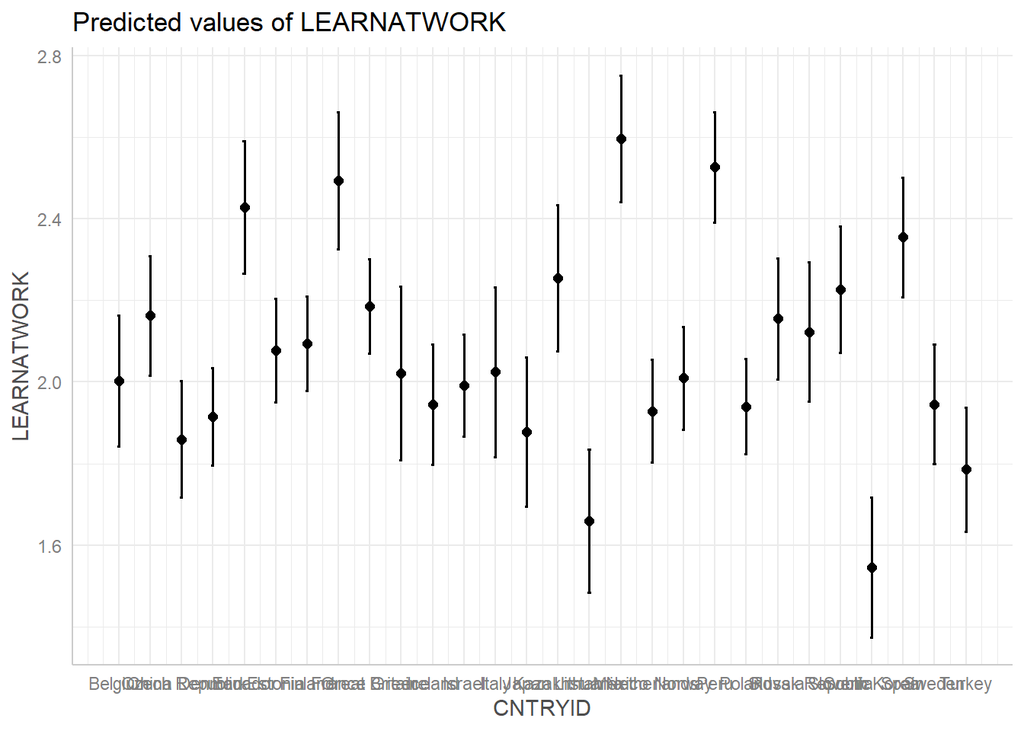

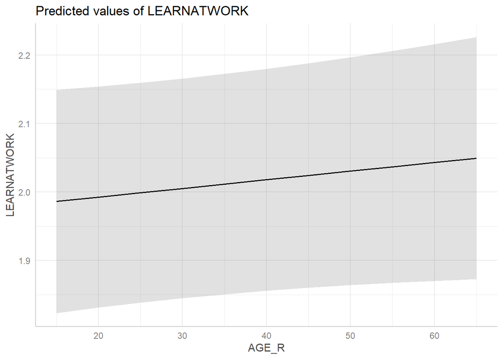

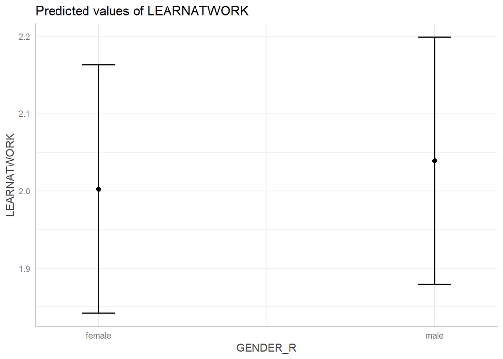

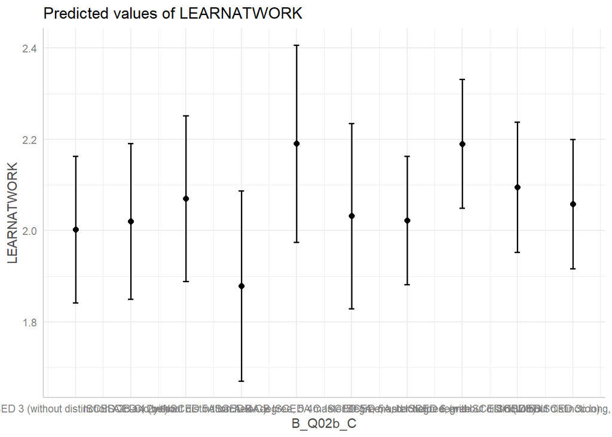

```r
plot(efs)
```